# Probability and Statistics

# Lab Assignment 1: Naive Bayes Classifier

## Work breakdown

- *Name1 Surname1*: Viktor Syrotiuk
- *Name2 Surname2*: Olena Dovbenchuk
- *Name3 Surname3*: Maksym Prokopets

## Introduction

During the first three weeks, you learned a couple of essential notions and theorems, and one of the most important among them is the **Bayes theorem**.

**Naive Bayes Classifier** is a simple algorithm, which is based on **Bayes theorem** and used for solving classification problems. **Classification problem** is a problem in which an observation has to be classified in one of the $n$ classes based on its similarity with observations in each class.

It is a **probabilistic classifier**, which means it predicts based on the probability of an observation belonging to each class. To compute it, this algorithm uses **Bayes’ formula,** that you probably already came across in **Lesson 3:**
$$\mathsf{P}(\mathrm{class}\mid
\mathrm{observation})=\frac{\mathsf{P}(\mathrm{observation}\mid\mathrm{class})\mathsf{P}(\mathrm{class})}{\mathsf{P}(\mathrm{observation})}$$

Under the strong **independence** assumption, one can calculate $\mathsf{P}(\mathrm{observation} \mid \mathrm{class})$ as
$$\mathsf{P}(\mathrm{observation}) =
\prod_{i=1}^{n} \mathsf{P}(\mathrm{feature}_i), \qquad
\mathsf{P}(\mathrm{observation} \mid \mathrm{class}) = \prod_{i=1}^{n}
\mathsf{P}(\mathrm{feature}_i \mid \mathrm{class}),$$
where $n$ is the total number of features describing a given observation (*For example, if an observation is presented as a sentence, then each word can be a feature*). Thus, $\mathsf{P}(\mathrm{class}|\mathrm{observation})$ now can be calculated as

$$\mathsf{P}(\mathrm{class} \mid
\mathrm{\mathrm{observation}}) = \mathsf{P}(\mathrm{class})\times
\prod_{i=1}^{n}\frac{\mathsf{P}(\mathrm{feature}_i\mid
\mathrm{class})}{\mathsf{P}(\mathrm{feature}_i)}\tag{1}$$

All the terms on the right-hand side can be estimated as corresponding relative frequencies using available data

**See [*this link*](https://www.javatpoint.com/machine-learning-naive-bayes-classifier) for more detailed explanations & examples :) Also you can watch [*this video*](https://youtu.be/O2L2Uv9pdDA?si=-ohkHVDuu3sLLGMq) for more examples!**

## Data description

There are 5 datasets uploaded on the cms (data.zip)

To determine your variant, take your team number from the list of teams on cms and take *mod 5* - this is the number of your data set.

- **0 - authors** This data set consists of citations of three famous writers: Edgar Alan Poe, Mary Wollstonecraft Shelley and HP Lovecraft. The task with this data set is to classify a piece of text with the author who was more likely to write it.
- **1 - discrimination** This data set consists of tweets that have discriminatory (sexism or racism) messages or of tweets that are of neutral mood. The task is to determine whether a given tweet has discriminatory mood or does not.
- **2 - fake news** This data set contains data of American news: a headline and an abstract of the article. Each piece of news is classified as fake or credible. The task is to classify the news from test.csv as credible or fake.
- **3 - sentiment** All the text messages contained in this data set are labeled with three sentiments: positive, neutral or negative. The task is to classify some text message as the one of positive mood, negative or neutral.
- **4 - spam** This last data set contains SMS messages classified as spam or non-spam (ham in the data set). The task is to determine whether a given message is spam or non-spam.

Each data set consists of two files: *train.csv* and *test.csv*. The first one is used to find the probabilities of the corresponding classes and the second one is used to test your classifier afterwards. Note that it is crucial to randomly split your data into training and testing parts to test the classifierʼs possibilities on the unseen data.

```r
# here goes a list of recommended libraries,
# though you may install other ones if they are needed
library(tidytext)
library(readr)
library(dplyr)
```

```r
library(ggplot2)
library(stringr)
```

## Outline of the work

1. **Data pre-processing** (includes removing punctuation marks and stop words, representing each message as a bag-of-words)
2. **Data visualization** (it’s time to plot your data!)
3. **Classifier implementation** (using the training set, calculate all the conditional probabilities in formula (1))
4. **Measurements of effectiveness of your classifier** (use the results from the previous step to predict classes for messages in the testing set and measure the accuracy, precision and recall, F1 score metric etc)
5. **Conclusions**

*!! do not forget to submit both the (compiled) Rmd source file and the .html output !!*

## Data pre-processing

- Read the *.csv* data files.
- Сlear your data from punctuation or other unneeded symbols.
- Clear you data from stop words. You don’t want words as is, and, or etc. to affect your probabilities distributions, so it is a wise decision to get rid of them. Find list of stop words in the cms under the lab task.
- Represent each test message as its bag-of-words. Here: https://machinelearningmastery.com/gentle-introduction-bag-words-model/ you can find general introduction to the bag-of-words model and examples on to create it.
- It is highly recommended to get familiar with R dataframes, it would make the work much easier to do.
- Useful links:
  - https://steviep42.github.io/webscraping/book/bagofwords.html#tidytext - example of using *tidytext* to count frequencies of the words.
  - Basics of Text Mining in R: http://rstudio-pubs-static.s3.amazonaws.com/256588_57b585da6c054349825cba46685d8464.html . Note that it also includes an example on how to create a bag of words from your text document.

```r
list.files(getwd())
```

```
## [1] "data"
## [2] "Lab1_Naive_Bayes_Classifier_Templatee-4.html"
## [3] "Lab1_Naive_Bayes_Classifier_Templatee-4.Rmd"
## [4] "Probability_LAB1.Rproj"
## [5] "README.md"
## [6] "stop_words.txt"
```

```r
list.files("data/1-discrimination")
```

```
## [1] "test.csv"  "train.csv"
```

```r
test_path1  <- "data/1-discrimination/test.csv"
train_path1 <- "data/1-discrimination/train.csv"

stop_words <- read_file("stop_words.txt")
# https://stackoverflow.com/questions/27195912/why-does-strsplit-return-a-list
splitted_stop_words <- strsplit(stop_words, split='\n')
splitted_stop_words <- splitted_stop_words[[1]]
splitted_stop_words <- trimws(splitted_stop_words)
```

```r
train <-  read.csv(file = train_path1, stringsAsFactors = FALSE)
test <-  read.csv(file = test_path1, stringsAsFactors = FALSE)
```

```r
tidy_text <- train %>%
  mutate(tweet = str_to_lower(tweet)) %>%
  mutate(tweet = str_replace_all(tweet, "user", " ")) %>%
  mutate(tweet = str_replace_all(tweet, "amp|\\bs\\b|\\bt\\b", " ")) %>%
  mutate(tweet = str_replace_all(tweet, "[^a-z\\s]", " ")) %>%
  mutate(tweet = str_replace_all(tweet, "\\s+", " ")) %>%
  unnest_tokens(word, tweet, token = "words") %>%
  filter(!word %in% splitted_stop_words,
         word != "",
         !is.na(word),
         str_length(word)>1)

word_counts <- tidy_text %>%
  count(word, sort = TRUE)
```

## Data visualization

Each time you work with some data, you need to understand it before you start processing it. R has very powerful tools to make nice plots and visualization. Show what are the most common words for negative and positive examples as a histogram, word cloud etc. Be creative!

```r
top_words <- tidy_text %>%
  group_by(label, word) %>%
  summarise(word_count = n(), .groups = 'drop') %>%
  group_by(label) %>%
  slice_max(word_count, n = 20) %>%
  ungroup()

head(top_words)
```

```
## # A tibble: 6 × 3
##   label   word    word_count
##   <chr>   <chr>        <int>
## 1 discrim trump          140
## 2 discrim white           99
## 3 discrim black           98
## 4 discrim libtard         98
## 5 discrim like            95
## 6 discrim racist          76
```

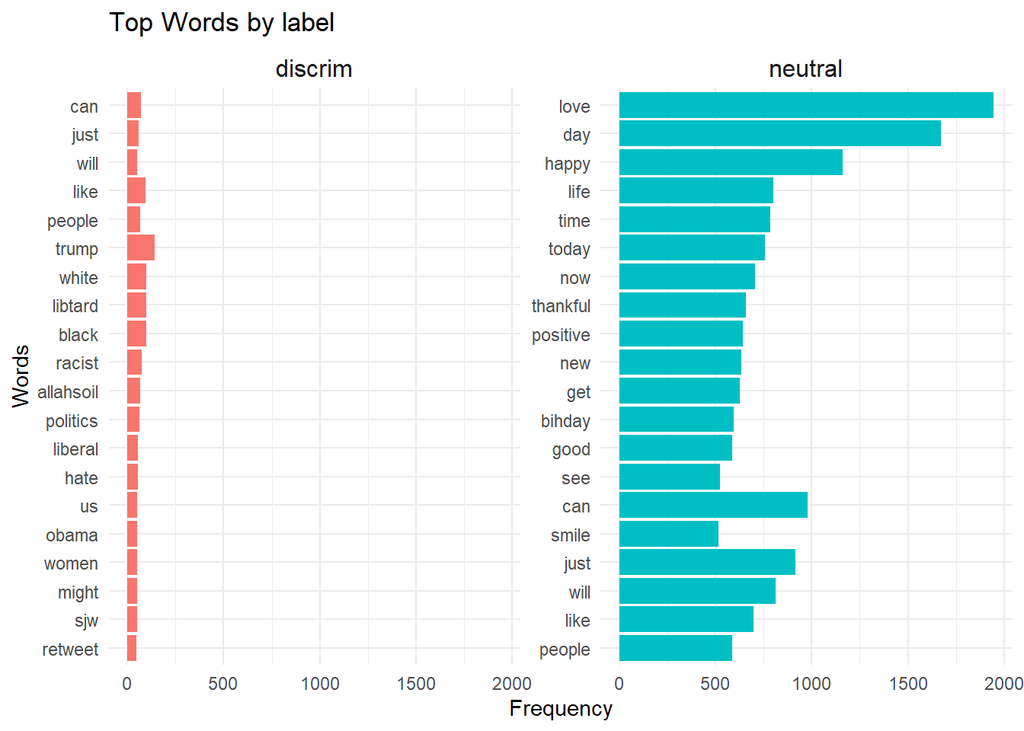

```r
ggplot(top_words, aes(x = reorder(word, word_count), y = word_count, fill = label)) +
  geom_col(show.legend = FALSE) +
  facet_wrap(~label, scales = "free_y") +
  coord_flip() +
  labs(x = "Words", y = "Frequency", title = "Top Words by label") +
  theme_minimal() +
  theme(strip.text = element_text(size = 12))
```

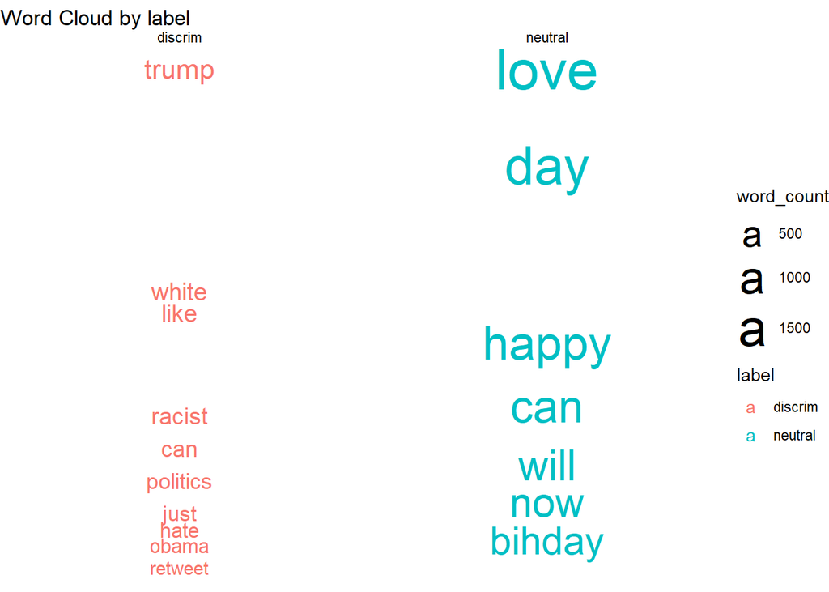

```r
ggplot(top_words, aes(x = 1, y = word_count, label = word, size = word_count, color = label)) +
  geom_text(check_overlap = TRUE) +
  facet_wrap(~label, scales = "free") +
  theme_void() +
  labs(title = "Word Cloud by label") +
  scale_size_continuous(range = c(4, 12))
```

## Classifier implementation

```r
head(tidy_text, 20)
```

```
##        X    id   label            word
## 1  17705 17706 discrim       allahsoil
## 2  17705 17706 discrim            term
## 3  17705 17706 discrim           jihad
## 4  17705 17706 discrim          highly
## 5  17705 17706 discrim       contested
## 6  17705 17706 discrim         concept
## 7  17705 17706 discrim         teambts
## 8  17705 17706 discrim teamsuperjunior
## 9  13439 13440 neutral          called
## 10 13439 13440 neutral        moderate
## 11 13439 13440 neutral         muslims
## 12 13439 13440 neutral            just
## 13 13439 13440 neutral           watch
## 14 13439 13440 neutral             say
## 15 13439 13440 neutral         nothing
## 16 30974 30975 neutral         ramadan
## 17 30974 30975 neutral         mubarak
## 18 30974 30975 neutral         muslims
## 19 30974 30975 neutral           world
## 20 30974 30975 neutral             may
```

```r
naiveBayes <- setRefClass("naiveBayes",
  fields = list(
    word_probs = "list",
    class_probs = "numeric",
    classes = "character",
    vocab = "character"
  ),

  methods = list(
    # Train the Naive Bayes classifier
    fit = function(X, y) {
      classes <<- as.character(unique(y))
      class_counts <- table(y)
      class_probs <<- as.numeric(class_counts / sum(class_counts))
      names(class_probs) <<- names(class_counts)
      vocab <<- unique(X$word)
      word_probs <<- list()

      # Calculate word probabilities for each class
      for(cl in classes) {
        words_cl <- X %>% filter(label == cl)
        word_counts <- table(words_cl$word)
        total <- sum(word_counts)
        probs <- as.numeric(word_counts) / total
        names(probs) <- names(word_counts)
        word_probs[[cl]] <<- probs
      }
    },

    # Predict class for a single message
    predict = function(message) {
      # Tokenize and preprocess the input message (same pipeline as training)
      tokens <- data.frame(tweet = message, stringsAsFactors = FALSE) %>%
        mutate(tweet = str_to_lower(tweet)) %>%
        mutate(tweet = str_replace_all(tweet, "user", " ")) %>%
        mutate(tweet = str_replace_all(tweet, "amp|\\bs\\b|\\bt\\b", " ")) %>%
        mutate(tweet = str_replace_all(tweet, "[^a-z\\s]", " ")) %>%
        mutate(tweet = str_replace_all(tweet, "\\s+", " ")) %>%
        unnest_tokens(word, tweet, token = "words") %>%
        filter(!word %in% splitted_stop_words,
               word != "",
               !is.na(word),
               str_length(word) > 1)

      words <- tokens$word

      if(length(words) == 0) {
        return(names(which.max(class_probs)))
      }

      log_probs <- numeric(length(classes))
      names(log_probs) <- classes

      for(cl in classes) {
        log_prob <- log(class_probs[cl])
        probs <- word_probs[[cl]]

        # Multiply word probabilities (sum logs for numerical stability)
        for(w in words) {
          if(w %in% names(probs)) {
            log_prob <- log_prob + log(probs[w])
          } else {
            # Use small epsilon for unknown words to avoid log(0)
            log_prob <- log_prob + log(.Machine$double.eps)
          }
        }

        log_probs[cl] <- log_prob
      }

      return(names(which.max(log_probs)))
    },

    # Evaluate model performance on test data
    score = function(X_test, y_test) {
      # Generate predictions for all test messages
      predictions <- sapply(X_test$tweet, function(msg) predict(msg))
      predictions <- as.character(predictions)
      y_test <- as.character(y_test)

      # Create confusion matrix
      cm <- table(Predicted = predictions, Actual = y_test)

      # Identify positive and negative classes
      class_counts <- table(y_test)
      pos_class <- names(which.min(class_counts))
      neg_class <- names(which.max(class_counts))

      TP <- ifelse(pos_class %in% rownames(cm), cm[pos_class, pos_class], 0)
      FP <- ifelse(pos_class %in% rownames(cm), cm[pos_class, neg_class], 0)
      FN <- ifelse(neg_class %in% rownames(cm), cm[neg_class, pos_class], 0)
      TN <- ifelse(neg_class %in% rownames(cm), cm[neg_class, neg_class], 0)

      accuracy <- (TP + TN) / sum(cm)
      precision <- ifelse((TP + FP) > 0, TP / (TP + FP), 0)
      recall <- ifelse((TP + FN) > 0, TP / (TP + FN), 0)
      F1 <- ifelse((precision + recall) > 0, 2 * precision * recall / (precision + recall), 0)

      error_details <- data.frame(
        tweet = X_test$tweet,
        predicted = predictions,
        actual = y_test,
        stringsAsFactors = FALSE
      )

      return(list(
        confusion_matrix = cm,
        accuracy = accuracy,
        precision = precision,
        recall = recall,
        F1 = F1,
        predictions = predictions,
        error_details = error_details,
        pos_class = pos_class,
        neg_class = neg_class
      ))
    }
  )
)

# Preprocess training data
tidy_train <- train %>%
  mutate(tweet = str_to_lower(tweet)) %>%
  mutate(tweet = str_replace_all(tweet, "user", " ")) %>%
  mutate(tweet = str_replace_all(tweet, "amp|\\bs\\b|\\bt\\b", " ")) %>%
  mutate(tweet = str_replace_all(tweet, "[^a-z\\s]", " ")) %>%
  mutate(tweet = str_replace_all(tweet, "\\s+", " ")) %>%
  unnest_tokens(word, tweet, token = "words") %>%
  filter(!word %in% splitted_stop_words,
         word != "",
         !is.na(word),
         str_length(word)>1) %>%
  select(word, label)

# Preprocess test data
tidy_test <- test %>%
  mutate(tweet = str_to_lower(tweet)) %>%
  mutate(tweet = str_replace_all(tweet, "user", " ")) %>%
  mutate(tweet = str_replace_all(tweet, "amp|\\bs\\b|\\bt\\b", " ")) %>%
  mutate(tweet = str_replace_all(tweet, "[^a-z\\s]", " ")) %>%
  mutate(tweet = str_replace_all(tweet, "\\s+", " ")) %>%
  unnest_tokens(word, tweet, token = "words") %>%
  filter(!word %in% splitted_stop_words,
         word != "",
         !is.na(word),
         str_length(word)>1)

# Train model on ALL training data
model <- naiveBayes$new()
model$fit(tidy_train, train$label)

# Test on REAL test set (test.csv)
results <- model$score(test, test$label)

cat("TEST SET RESULTS (test.csv)\n")
```

```
## TEST SET RESULTS (test.csv)
```

```r
cat(sprintf("Accuracy: %.3f\n", results$accuracy))
```

```
## Accuracy: 0.956
```

```r
cat(sprintf("Precision: %.3f\n", results$precision))
```

```
## Precision: 0.748
```

```r
cat(sprintf("Recall: %.3f\n", results$recall))
```

```
## Recall: 0.557
```

```r
cat(sprintf("F1: %.3f\n", results$F1))
```

```
## F1: 0.639
```

```r
failure_cases <- results$error_details[results$error_details$predicted != results$error_details$actual, ]
```

## Measure effectiveness of your classifier

- Note that accuracy is not always a good metric for your classifier. Look at precision and recall curves, F1 score metric.

  When evaluating the model, it’s important to understand the different types of classification results:
  - A *true positive* result is one where the model correctly predicts the positive class.
  - A *true negative* result is one where the model correctly predicts the negative class.
  - A *false positive* result is one where the model incorrectly predicts the positive class when it is actually negative.
  - A *false negative* result is one where the model incorrectly predicts the negative class when it is actually positive.

  Precision measures the proportion of true positive predictions among all positive predictions made by the model.

  $$Precision = \frac{TP}{TP+FP}$$

  Recall, on the other hand, measures the proportion of true positives identified out of all actual positive cases.

  $$Recall = \frac{TP}{TP+FN}$$

  F1 score is the harmonic mean of both precision and recall.

  $$F1 = \frac{2\times Precision \times Recall}{Precision + Recall}$$

  **See [this link](https://cohere.com/blog/classification-eval-metrics) to find more information about metrics.**

### Failure Cases

```r
errors <- results$error_details[results$error_details$predicted != results$error_details$actual, ]
classes <- unique(c(results$error_details$predicted, results$error_details$actual))

FP <- sum(results$error_details$predicted == classes[1] & results$error_details$actual == classes[2])
FN <- sum(results$error_details$predicted == classes[2] & results$error_details$actual == classes[1])

cat(sprintf("Errors: %d/%d cases (%.1f%%) - False Positives: %d, False Negatives: %d\n",
            nrow(errors), nrow(results$error_details),
            nrow(errors)/nrow(results$error_details)*100, FP, FN))
```

[output not shown]

### Visualization

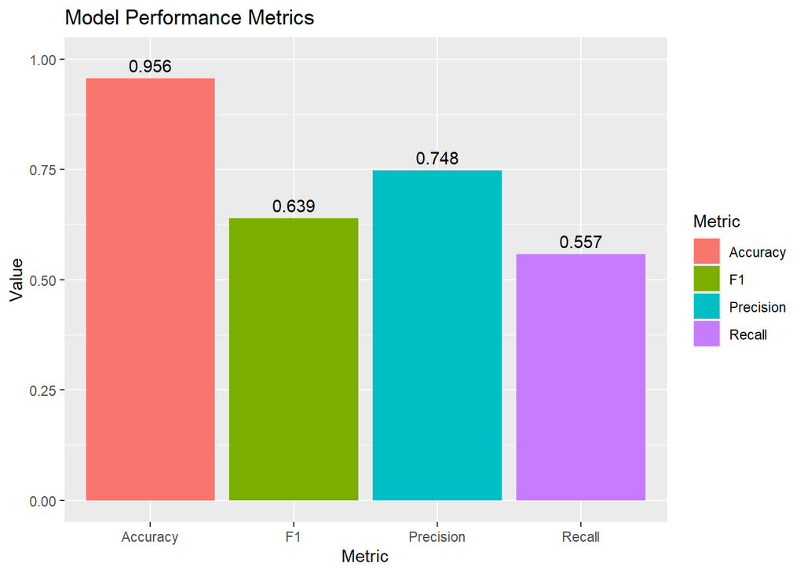

```r
metrics <- data.frame(
  Metric = c("Accuracy", "Precision", "Recall", "F1"),
  Value = c(results$accuracy, results$precision, results$recall, results$F1)
)

ggplot(metrics, aes(x = Metric, y = Value, fill = Metric)) +
  geom_bar(stat = "identity") +
  geom_text(aes(label = sprintf("%.3f", Value)), vjust = -0.5) +
  ylim(0, 1) +
  ggtitle("Model Performance Metrics")
```

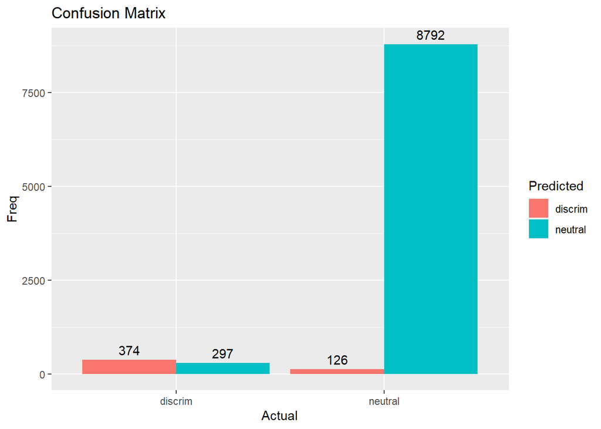

```r
conf_matrix <- as.data.frame(results$confusion_matrix)
ggplot(conf_matrix, aes(x = Actual, y = Freq, fill = Predicted)) +
  geom_bar(stat = "identity", position = "dodge") +
  geom_text(aes(label = Freq), position = position_dodge(width = 0.9), vjust = -0.5) +
  ggtitle("Confusion Matrix")
```

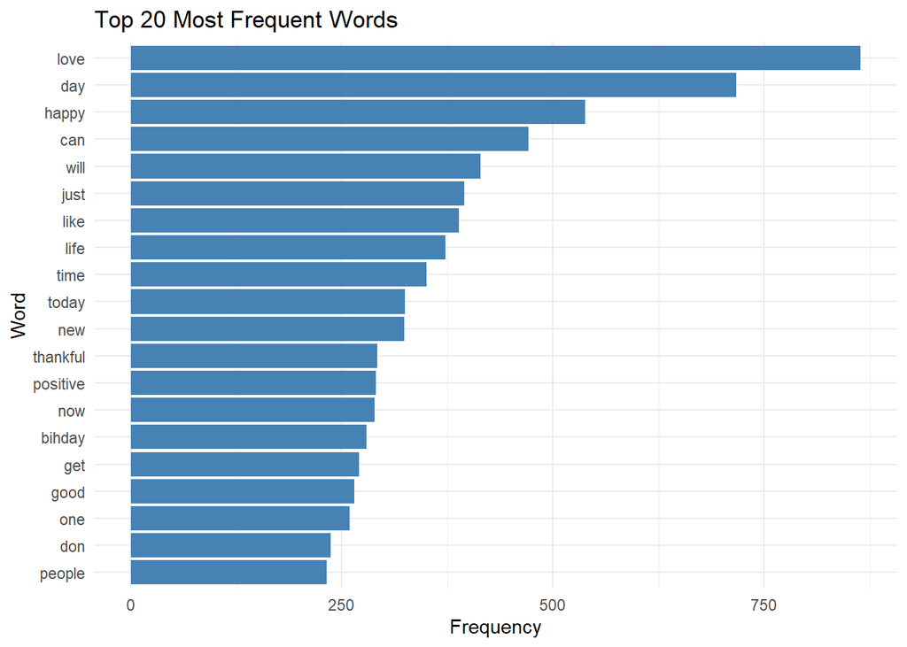

```r
# Top words visualization - corrected sorting
top_words <- tidy_test %>%
  count(word, sort = TRUE) %>%
  head(20) %>%
  arrange(n)  # Sort by frequency for proper bar order

ggplot(top_words, aes(x = reorder(word, n), y = n)) +
  geom_bar(stat = "identity", fill = "steelblue") +
  coord_flip() +
  ggtitle("Top 20 Most Frequent Words") +
  xlab("Word") +
  ylab("Frequency") +
  theme_minimal()
```

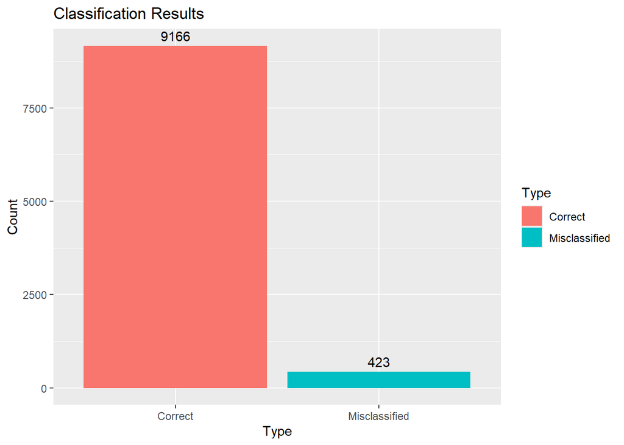

```r
# Error analysis plot
error_details <- results$error_details
misclassified <- error_details[error_details$predicted != error_details$actual, ]

error_counts <- data.frame(
  Type = c("Correct", "Misclassified"),
  Count = c(nrow(error_details) - nrow(misclassified), nrow(misclassified))
)

ggplot(error_counts, aes(x = Type, y = Count, fill = Type)) +
  geom_bar(stat = "identity") +
  geom_text(aes(label = Count), vjust = -0.5) +
  ggtitle("Classification Results")
```

## Conclusions

In this work, we implemented a Naive Bayes classifier for text classification. The method is grounded in Bayes’ theorem, which gives the conditional probability of a class given an observation:

In this way, every part of the Naive Bayes class directly reflects concepts from probability theory: priors, likelihoods, posteriors, and evaluation through conditional probabilities.

## Pros and Cons of Naive Bayes

**Advantages:**

- Very simple and efficient to implement, even on large datasets.
- Works well with high-dimensional data like text, because it reduces the problem to counting word frequencies.
- Requires relatively little training data compared to more complex models.

**Limitations:**

- The independence assumption is rarely true in real language, since words are often correlated (e.g., “not good” has a very different meaning than the independent probabilities of “not” and “good”).
- It does not capture word order or context (bag-of-words model).
- Zero-probability problems may occur with unseen words, which we mitigated by using a very small epsilon.

## Why Accuracy Is Not Enough

While accuracy measures the proportion of all correct predictions, it can be misleading in imbalanced datasets.  
For example, if 90% of tweets are neutral, a model that always predicts “neutral” would still have 90% accuracy — even though it learned nothing useful.

This is why **precision**, **recall**, and **F1 score** are important:

- **Precision** focuses on the reliability of positive predictions  
  $Precision = \dfrac{TP}{TP + FP}$
- **Recall** measures the ability to detect all actual positives  
  $Recall = \dfrac{TP}{TP + FN}$
- **F1 score** combines both into a single balanced metric  
  $F1 = \dfrac{2 \times Precision \times Recall}{Precision + Recall}$

For classification tasks like discrimination detection, where both false negatives and false positives are critical, the **F1 score** is a much more informative metric than accuracy alone.